# Forced Displacement in Colombia

Manuela Szinovatz

The following analysis is based on data from the Colombian governmental organisation Unidad Victimas, that is in charge of registering the victims of Colombia’s Armed Conflict. The data can be downloaded here: https://cifras.unidadvictimas.gov.co/

Check out the interactive map showing the total number of displaced people in each department of Colombian.

[interactive chart not shown]

Each department is made up of several municipalities. The following table lists the total number of displacements in each municipality per year. Find out where and when most people got displaced, where they arrived and how the population developed in the various municipalities.

|  | Municipality | Year | Displaced | Settled | Difference |
| --- | --- | --- | --- | --- | --- |
| 1 | Buenaventura | 2014 | 51321 | 28912 | -22409 |
| 2 | El Carmen De Bolivar | 2000 | 43311 | 24318 | -18993 |
| 3 | Buenaventura | 2013 | 38719 | 21321 | -17398 |
| 4 | Santa Marta | 2002 | 27609 | 27878 | 269 |
| 5 | Buenaventura | 2011 | 24623 | 8286 | -16337 |
| 6 | Buenaventura | 2015 | 23944 | 19314 | -4630 |
| 7 | Buenaventura | 2012 | 22724 | 10858 | -11866 |
| 8 | El Charco | 2007 | 21308 | 16764 | -4544 |
| 9 | Valledupar | 2002 | 19528 | 26014 | 6486 |
| 10 | El Carmen De Bolivar | 2001 | 19053 | 8419 | -10634 |

[output cut: 21746 more lines]

## Displacement in Buenaventura

According to the data above, Buenaventura has the highest number of displaced people in only one year. In 2014 a total of 51,321 people were forced to leave their homes. Since 28,912 victims also settled down in Buenaventura that year, one can suspect that approximately half of them stayed in that municipality. On the other hand, at least 22,409 people left Buenaventura in 2014, which is the highest loss of population in one year. The following chart shows how this relation between people leaving and settling down developed over time.

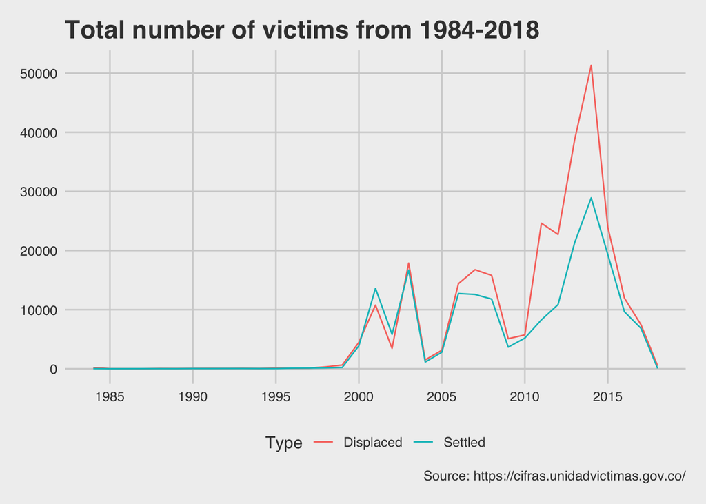

## Displacement in Medellín

The following chart illustrates the relation between people that were forcefully displaced and people arriving in Medellín because of forced displacement. Here, the ones settling down by far exceed those leaving the municipality. The only place that received more displaced people than Medellín is Colombia’s capital Bogotá, a city three times the size of Medellín in terms of population.

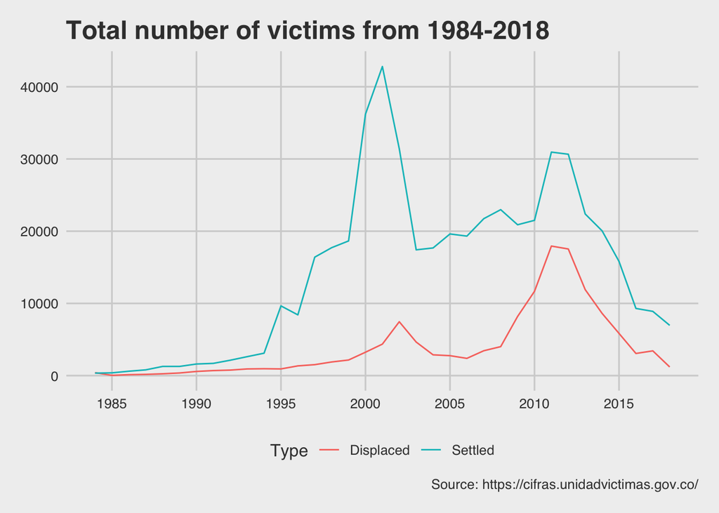

## Population Change in Buenaventura and Medellín

Finally the following chart sums up how forced displacement has influenced the population of Buenaventura and Medellín over the course of the last 20 years.

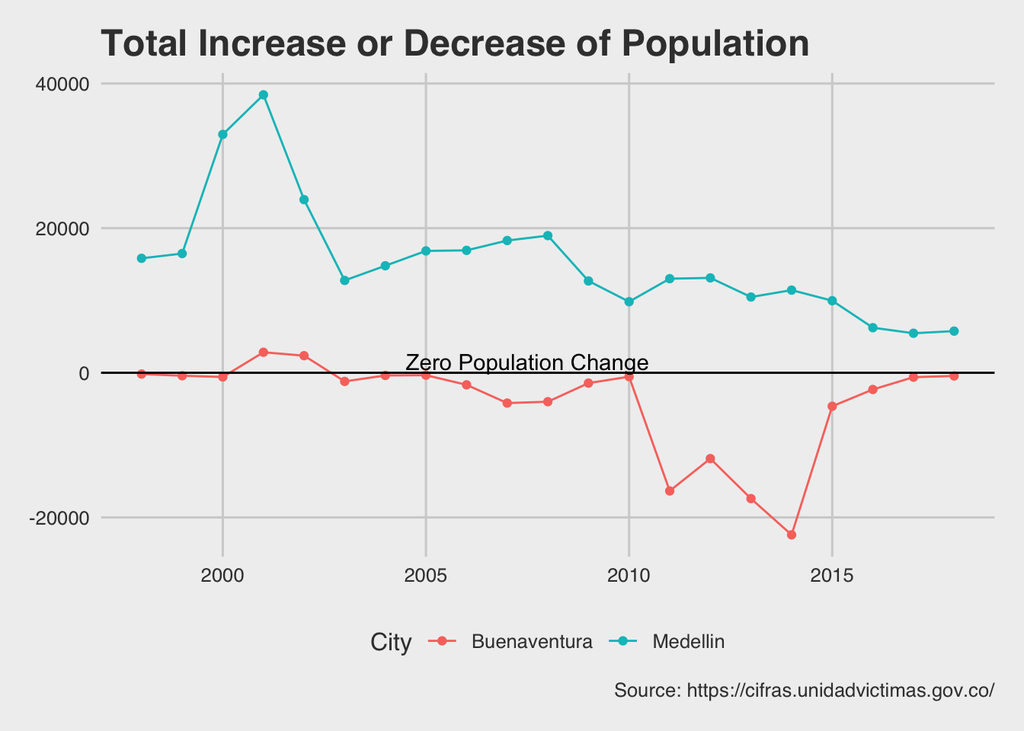